# lab8 answers

sbsambado

2/21/2021

# Answers for Lab 8

**Question 1** 1 point for background/context, -0.5 for uncited sources

**Question 2** 0.5 point for visualization, 0.5 for identification of predictors (SolarR, Wind, and Temp could all be predictors; Month could be justified as predictor or random effect; Day could be random effect but may not be important)

**Question 3** 0.5 point for checking that there is a linear relationship between predictors and response. 0.5 point for addressing outliers (points 117 and possibly 62; either run model with/without them or log transform Ozone) remember, not all predictors need to be normal as long as the model residuals are normal

**Question 4** 1 point for linear model with correctly checking residuals

**Question 5** 2 points (each model, with correctly checked residuals, is 1 point)

**Question 6** 1 point for nicely formatted table with df, AIC, BIC, and adj.r.sq

**Question 7** 1 point for justification of model choice; 1.5 point for prediction/assessment of fit

0.5 point for formatting/style/overall professional appearance of assignment

*Notes*

ALL HOMEWORK SHOULD BE SUBMITTED AS A KNITTED HOMEWORK FILE (.PDF or .HTML)

- -2.0 points if HW not in right format
- -.25 point if code is not annotated
- -.25 point if answers are not in complete sentences
- -.25 point if code does not seem adequate to answer question

**Question 1** Pretty much any background info is fine.

**Question 2: Visualize**

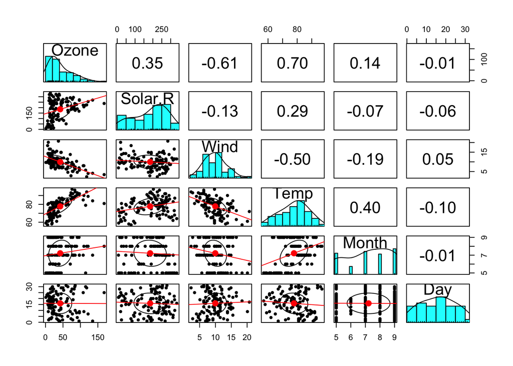

```r
#must use pairs plots
pairs.panels(airqual, lm = T) #discuss which variables have linear relationships
```

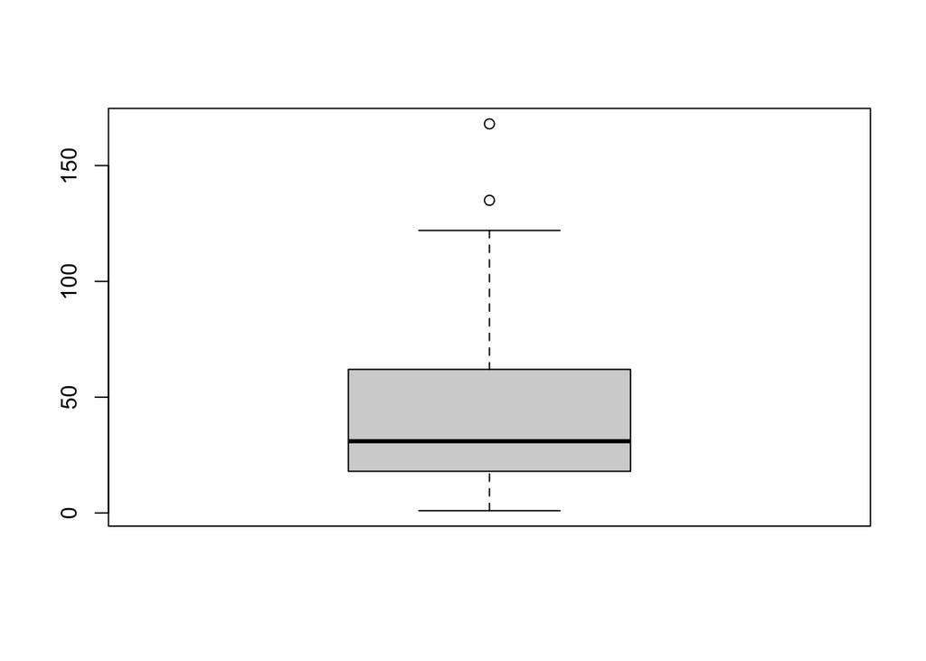

```r
#optional: boxplot - remember this doesn't have to be normal
boxplot(airqual$Ozone)
```

**Question 3: Check assumptions**

```r
fit_solar <- lm(Ozone~Solar.R, data = airqual)
fit_wind <- lm(Ozone~Wind, data = airqual)
fit_temp <- lm(Ozone~Temp, data = airqual)
fit_all <- lm(Ozone~Temp+Wind+Solar.R, data = airqual)

res_S <- resid(fit_solar)
res_W <- resid(fit_wind)
res_T <- resid(fit_temp)
res_A <- resid(fit_all)

op <- par(mfrow = c(2,2))
qqPlot(res_S)
```

```
## 117  62
##  77  34
```

```r
qqPlot(res_W)
```

```
## 117  62
##  77  34
```

```r
qqPlot(res_T)
```

```
## 117  62
##  77  34
```

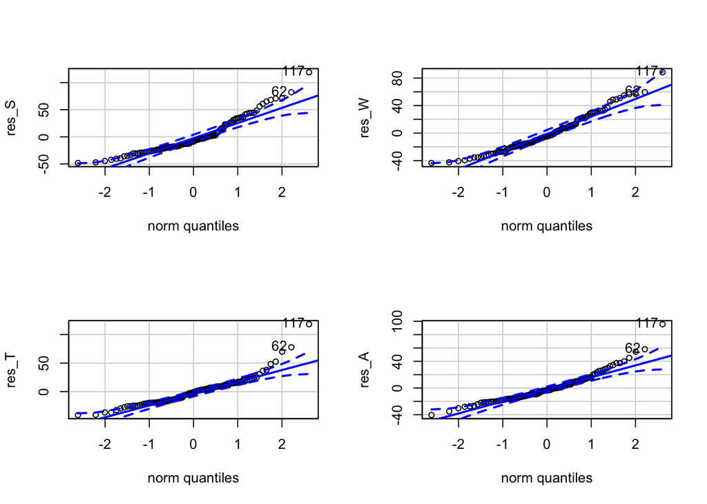

```
## 117  62
##  77  34
```

```r
qqPlot(res_A)
```

```r
par(op)

logfit_solar <- lm(log(Ozone)~Solar.R, data = airqual)
logfit_wind <- lm(log(Ozone)~Wind, data = airqual)
logfit_temp <- lm(log(Ozone)~Temp, data = airqual)
logfit_all <- lm(log(Ozone)~Temp+Wind+Solar.R, data = airqual)

logres_S <- resid(logfit_solar)
logres_W <- resid(logfit_wind)
logres_T <- resid(logfit_temp)
logres_A <- resid(logfit_all)

op <- par(mfrow = c(2,2))
qqPlot(logres_S)
```

```
## 21 22
## 17 18
```

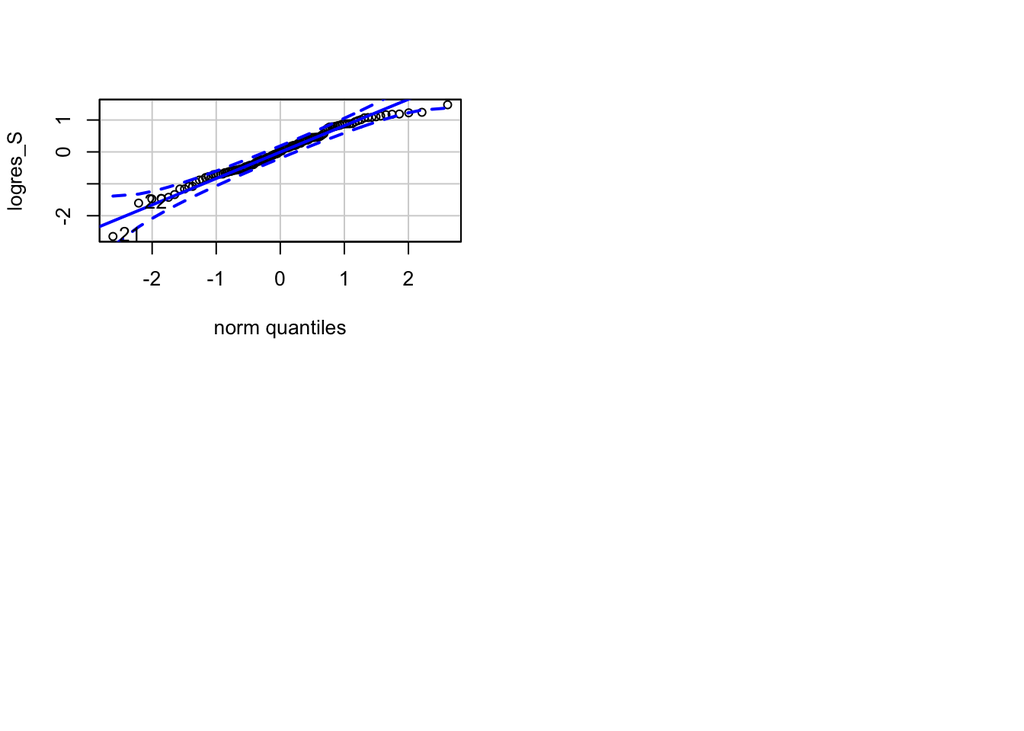

```r
par(op)
```

**Question 4,5** Any models are fine

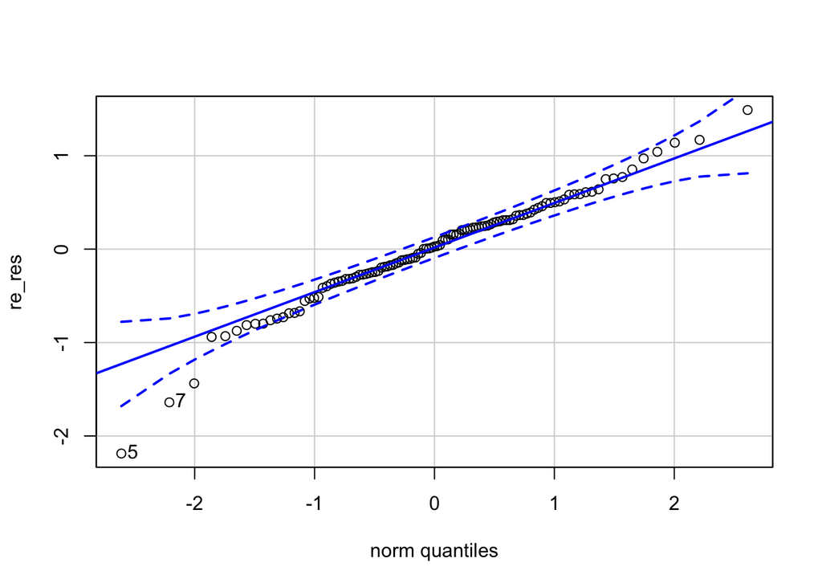

```
##  5  7
## 17 45
```

```r
#random effects example
re_model <- lme(log(Ozone) ~ Temp, random = ~1|Month, data = na.omit(airqual))
re_res <- resid(re_model)
qqPlot(re_res)
```

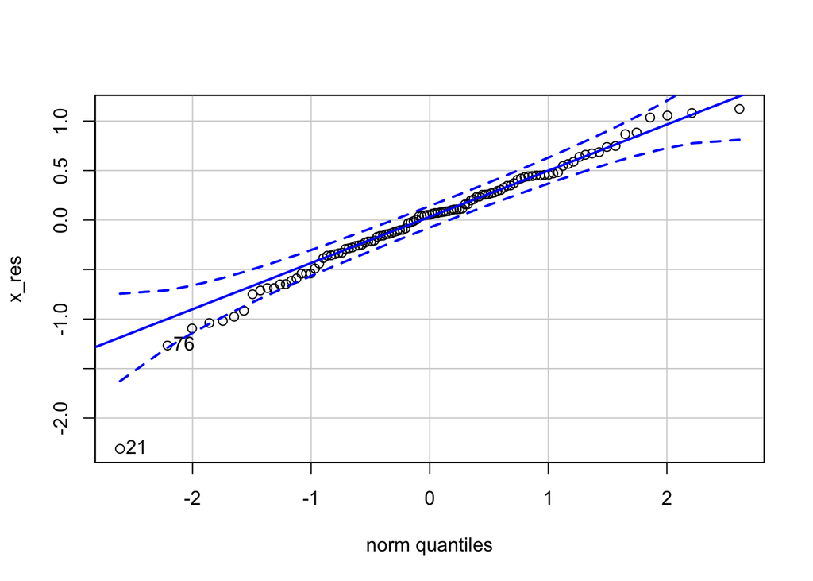

```
## 21 76
## 17 45
```

```r
#interaction example
x_model <- lm(log(Ozone) ~ Temp*Wind, data = airqual)
x_res <- resid(x_model)
qqPlot(x_res)
```

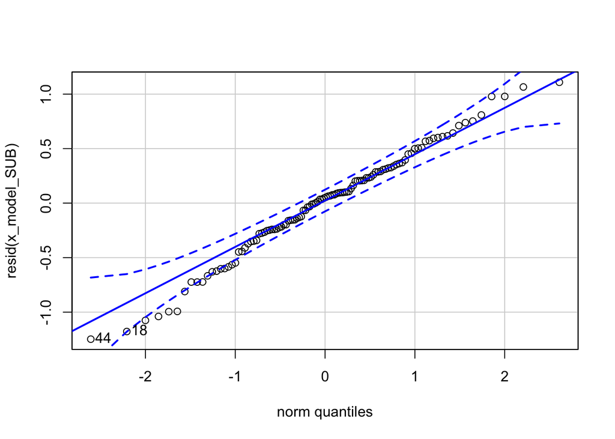

```
## [1] 44 18
```

```r
#check models with and without outliers
sub_airq <- dplyr::filter(airqual, Ozone != 1) #better way to get rid of row 21?
x_model_SUB <- lm(log(Ozone) ~ Temp*Wind, data = sub_airq)
qqPlot(resid(x_model_SUB))
```

**Question 6**

```r
result <- AIC(logfit_solar,logfit_all, logfit_temp, logfit_wind, x_model) #this will create a dataframe whose rownames are the models, with columns for the df and AIC of each model # don't run re_model cause made with lme

#add other metrics to your table
models <- list(logfit_solar,logfit_all, logfit_temp, logfit_wind, x_model) #make sure you keep your models in the same order here as they were when you created your results table
result$BIC <- sapply(models, BIC) #add a column for BIC to the results

#result$AICc <- result$AIC+ (2*(result$df-2)^2+2*(result$df-2))/(153-1-(result$df-2))
#AICc doesn't make a difference bc sample size is big enough

model_summary <- lapply(models, summary) #look up ?lapply if you have not used this function before

#now we will use a for loop to easily extract the R^2 and adj R^2 value for each model from its summary, and store them in new columns in the results table

for(i in 1:(length(models)-1)){ #this creates a variable i that starts with the value i=1
  result$rsq[i] <- model_summary[[i]]$r.squared #we assign the rsq value from model i to the i'th row of the column 'rsq' in the table 'results'
  result$adj_rsq[i] <- model_summary[[i]]$adj.r.squared #same for adjusted rsq
} #now we go back to the beginning of the for-loop, add 1 to the value of i, and do everything again


kable(result, digits = 2, align = "c")
```

|  | df | AIC | BIC | rsq | adj_rsq |
| --- | --- | --- | --- | --- | --- |
| logfit_solar | 3 | 262.14 | 270.27 | 0.21 | 0.20 |
| logfit_all | 5 | 170.83 | 184.37 | 0.66 | 0.66 |
| logfit_temp | 3 | 198.21 | 206.34 | 0.55 | 0.55 |
| logfit_wind | 3 | 247.03 | 255.16 | 0.31 | 0.30 |
| x_model | 5 | 187.20 | 200.75 | 0.21 | 0.20 |

**Question 7** Best model here is logfit_all based on AIC, BIC, R2 but it doesn’t do that well predicting

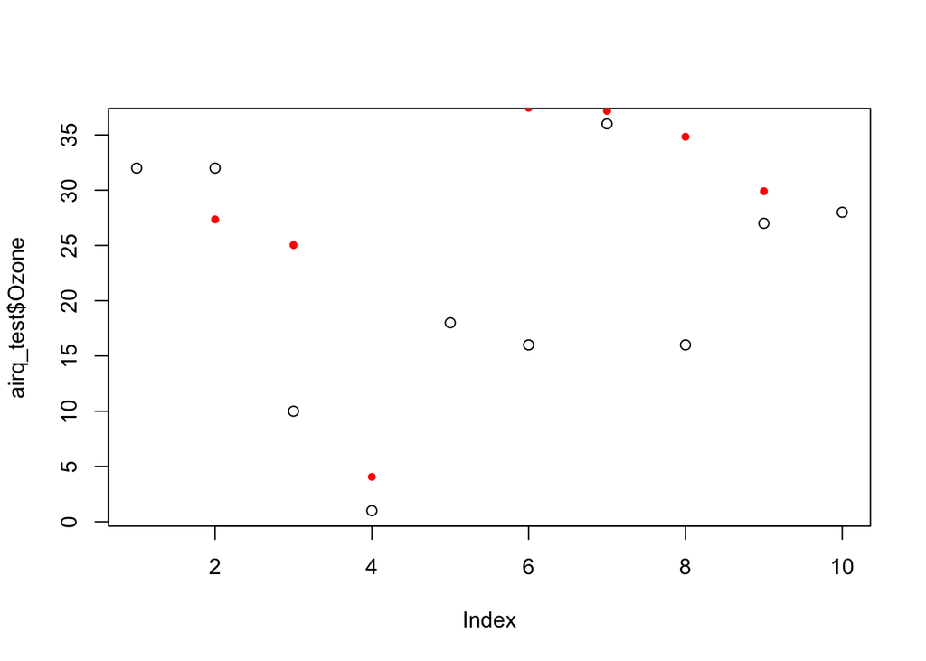

```r
splitter <- sample(1:nrow(airqual), 10, replace = F) #pick 15 random rows from plant_sub to reserve as test data
airq_train <- airqual[-splitter,] #leave those rows out of the training data
airq_test <- airqual[splitter,] #use them to create a set of test data

final_fit <- lm(Ozone ~ Solar.R + Wind + Temp, data = airq_train) #fit the final model, using JUST your training set as the data argument

prediction <- predict(final_fit,airq_test) #use the fitted model to predict values for your test data

plot(airq_test$Ozone, pch=1) #plot the actual test data values
points(prediction, pch=20, col = "red") #plot the model predictions for those points
```